# Alignment and feature counting

November 2025

## Single Cell RNAseq Analysis Workflow

[figure not shown]

Image by [Stephanie Hicks](https://speakerdeck.com/stephaniehicks/welcome-to-the-world-of-single-cell-rna-sequencing?slide=3) via [learn.gencore.bio.nyu.edu](https://learn.gencore.bio.nyu.edu/single-cell-rnaseq/)

## Single Cell RNAseq Analysis Workflow

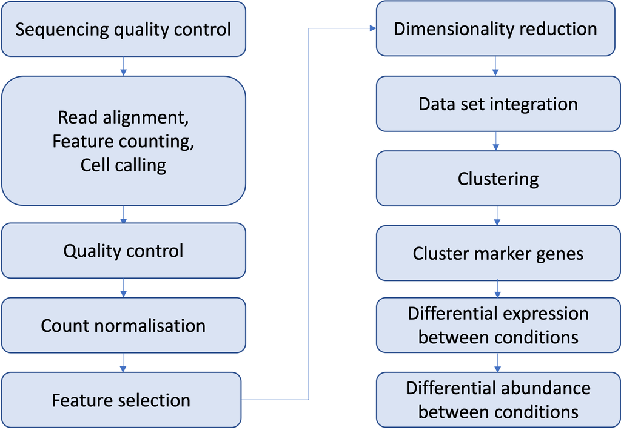

## 10x single-cell isolation

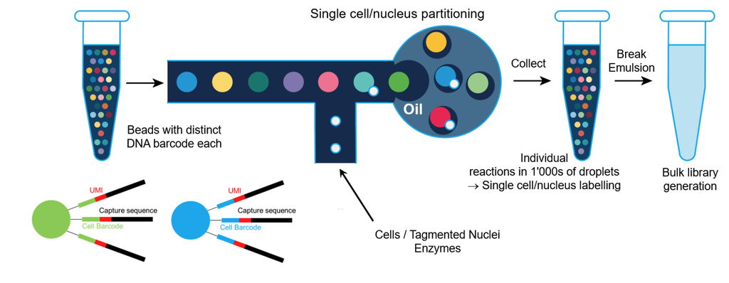

Image from https://wp.unil.ch/gtf/single-cell-experiments-10x/

## 10x library file structure

The 10x library contains four pieces of information, in the form of DNA sequences, for each “read”.

- **sample index** - identifies the library, with one or two indexes per sample
- **10x barcode (BC)** - identifies the droplet in the library
- **UMI (Unique Molecular Identifier)** - identifies the transcript molecule within a cell and gene
- **insert** - the transcript molecule

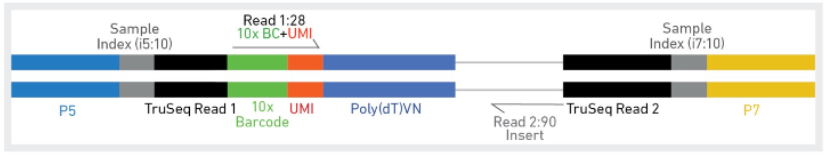

- TruSeq Read 1: Read 1 primer
- TruSeq Read 2: Read 2 primer
- P5 and P7 are short DNA adapter sequences that allow the library to bind to the Illumina flow cell

Image from [10x Genomics](https://kb.10xgenomics.com/s/article/360000939852-What-is-the-difference-between-Single-Cell-3-and-5-Gene-Expression-libraries)

## Raw fastq files

The sequences for any given fragment will generally be delivered in 3 or 4 files:

- **I1**: I7 sample index
- **I2**: I5 sample index if present (dual indexing only)
- **R1**: 10x barcode + UMI
- **R2**: insert sequence

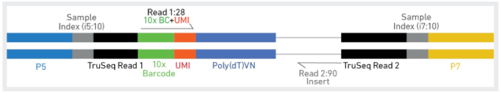

## QC of Raw Reads - FASTQC

[figure not shown]

## QC of Raw Reads - MultiQC - General Statistics

[figure not shown]

## QC of Raw Reads - MultiQC - Sequence Quality Histograms

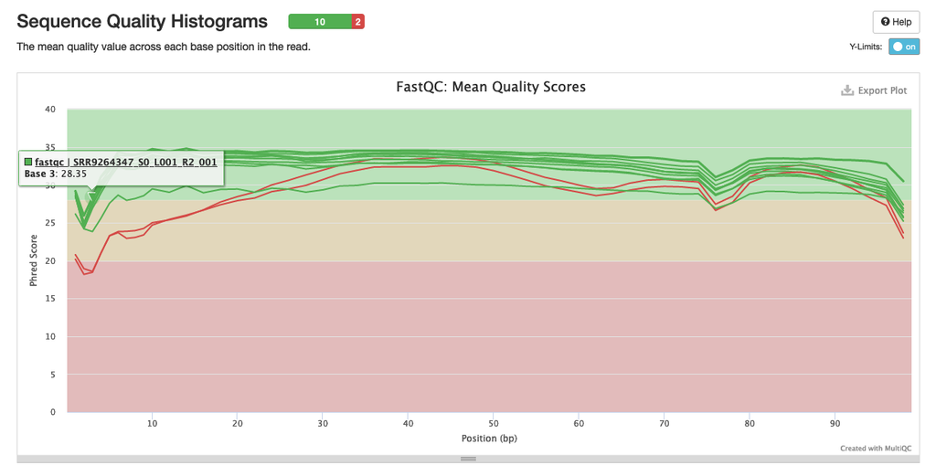

## Alignment and counting

The first steps in the analysis of single cell RNAseq data:

- Align reads to genome
- Annotate reads with feature (gene)
- Quantify gene expression

## Cell Ranger

- 10x Cell Ranger - This not only carries out the alignment and feature counting, but will also:
  - Call cells
  - Generate a summary report in html format
  - Generate a “cloupe” file

Alternative methods include:

- STAR solo:
  - Generates outputs very similar to CellRanger minus the cloupe file and the QC report
  - Will run with lower memory requirements in a shorter time than Cell Ranger
- Alevin:
  - Based on the popular Salmon tool for bulk RNAseq feature counting
  - Alevin supports both 10x-Chromium and Drop-seq derived data

## Obtaining Cell Ranger

[figure not shown]

Setup instructions given in the course materials homepage.

## Cell Ranger tools

Cell Ranger includes a number of different tools for analysing scRNAseq data, including:

- `cellranger mkref` - for making custom references
- `cellranger count` - for aligning reads and generating a count matrix
- `cellranger aggr` - for combining multiple samples and normalising the counts

## Preparing the raw fastq files

Cell Ranger requires the fastq file names to follow a convention:

```
<SampleName>_S<SampleNumber>_L00<Lane>_<Read>_001.fastq.gz
```

e.g. for a single sample in the Caron data set we have:

```
    SRR9264343_S0_L001_I1_001.fastq.gz
    SRR9264343_S0_L001_R1_001.fastq.gz
    SRR9264343_S0_L001_R2_001.fastq.gz
```

## Genome/Transcriptome Reference

As with other aligners Cell Ranger requires the information about the genome and transcriptome of interest to be provided in a specific format.

- Obtain from the 10x website for human or mouse (or both - PDX)
- Build a custom reference with `cellranger mkref`

```bash
cellranger mkref \
  --fasta={GENOME FASTA} \
  --genes={ANNOTATION GTF} \
  --genome={OUTPUT FOLDER FOR INDEX} \
  --nthreads={CPUS}
```

## Running `cellranger count`

- Computationally very intensive
- High memory requirements

```bash
cellranger count \
  --id={OUTPUT_SAMPLE_NAME} \
  --transcriptome={DIRECTORY_WITH_REFERENCE} \
  --fastqs={DIRECTORY_WITH_FASTQ_FILES} \
  --sample={NAME_OF_SAMPLE_IN_FASTQ_FILES} \
  --localcores={NUMBER_OF_CPUS} \
  --localmem={RAM_MEMORY}
```

## Cell Ranger outputs

- One directory per sample

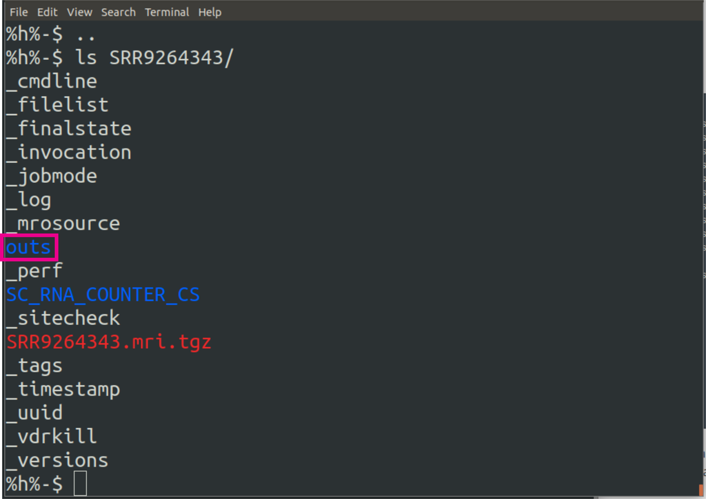

## Cell Ranger outputs

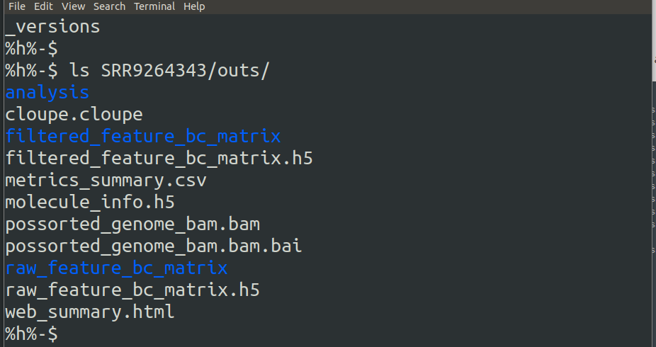

## Cell Ranger outputs

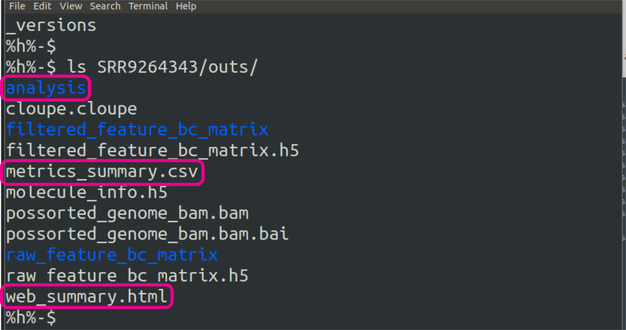

## Cell Ranger report

[figure not shown]

## Cell Ranger outputs

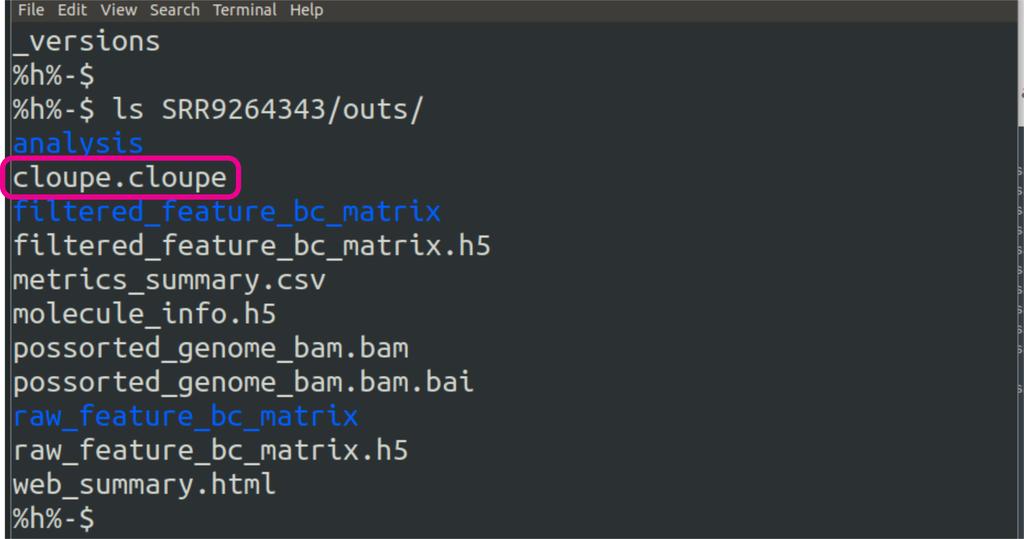

## Loupe Browser

[figure not shown]

## Cell Ranger outputs

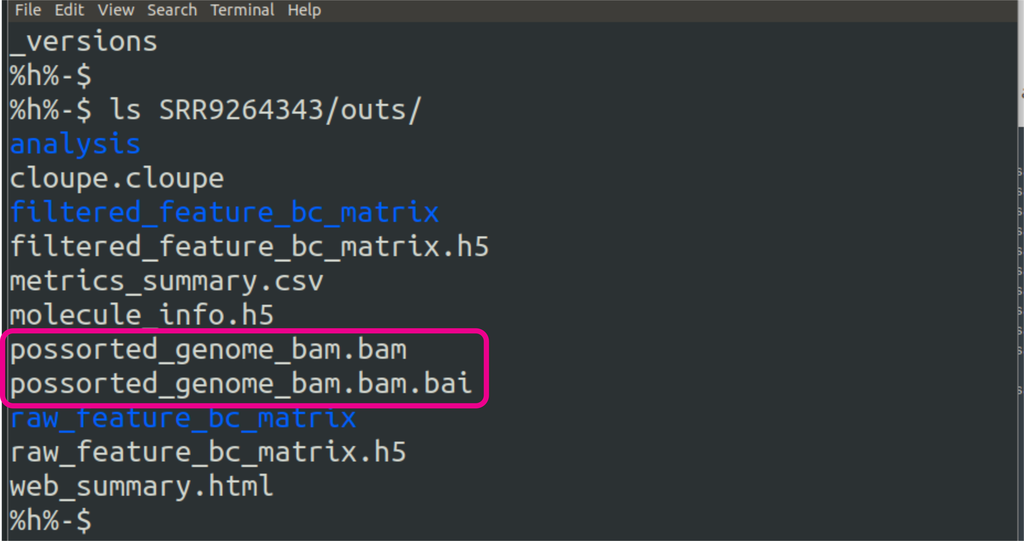

## Cell Ranger outputs

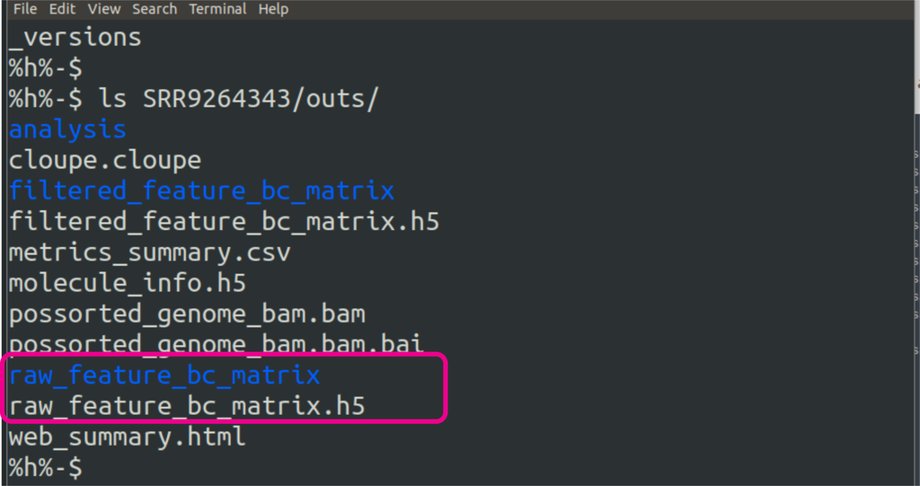

## Cell Ranger outputs

Two types of outputs:

- Text-based files: `.tsv` and `.mtx`
- HDF5 files: `.h5`

Both of these can be read by standard scRNA-seq analysis packages and contain data for a  
**unique molecular identified (UMI) count matrix**:

[figure not shown]

## Cell Ranger outputs

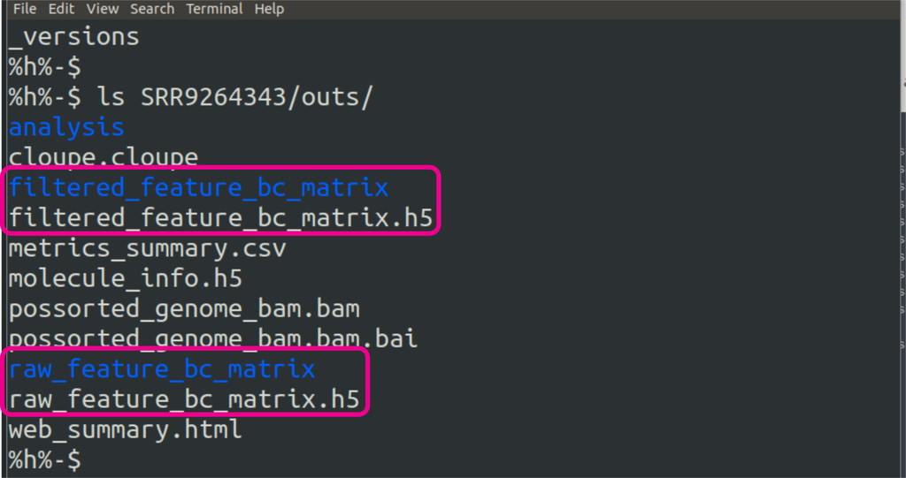

## Cell Ranger cell calling

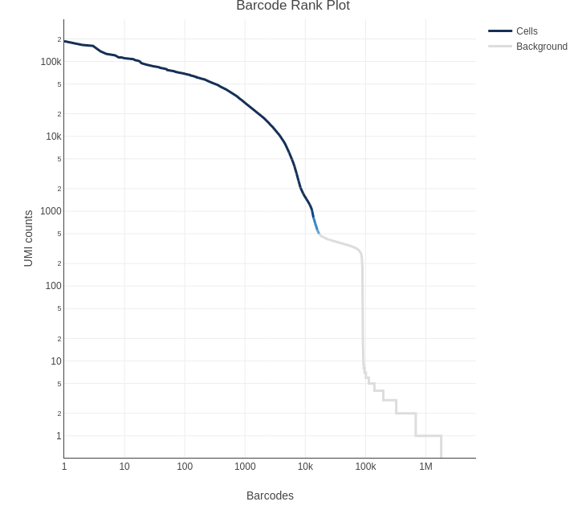

## Single Cell RNAseq Analysis Workflow

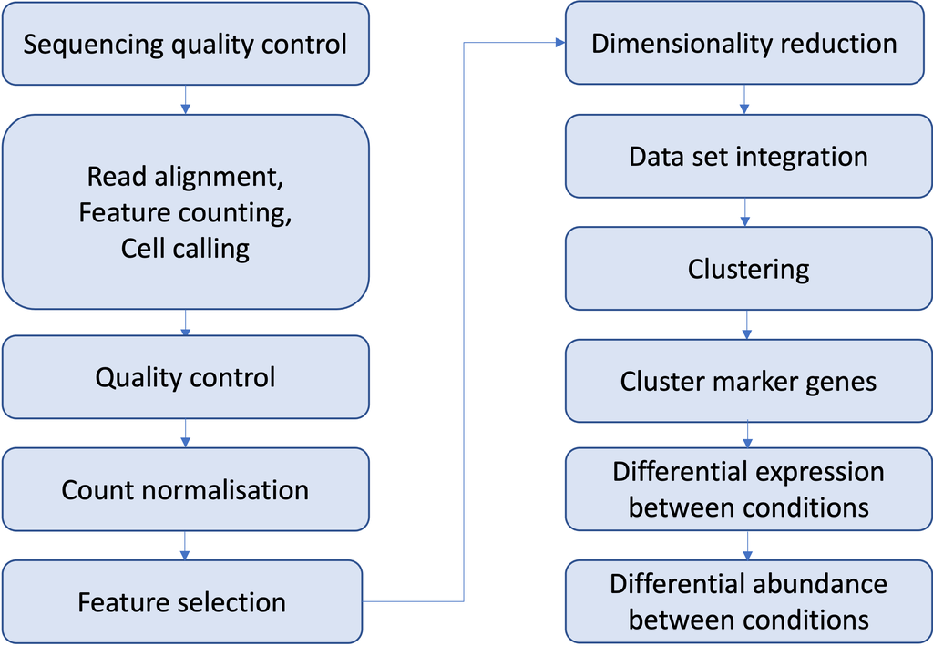